# NLP Lab3 - Levenshtein distance and spelling corrections

**Author: Bartłomiej Jamiołkowski**

The task introduces the Levenshtein distance - a measure that is useful in tasks such as approximate string matching.

```python
from datasets import load_dataset
from spacy.tokenizer import Tokenizer
from spacy.lang.pl import Polish
from collections import Counter
from elasticsearch import Elasticsearch, helpers
from morfeusz2 import Morfeusz
import matplotlib.pyplot as plt
import random
import string
import math
import time
import numpy as np
import pandas as pd
pd.set_option('display.max_colwidth', None)

import warnings
warnings.filterwarnings('ignore')
```

## Task 1

Use FIQA-PL corpus, including documents, questions and relations between them.

```python
fiqa_pl = load_dataset('clarin-knext/fiqa-pl', 'corpus')
fiqa_pl_df = fiqa_pl['corpus'].to_pandas()
data = [row['text'].lower() for _, row in fiqa_pl_df.iterrows()]
```

## Task 2

Use SpaCy [tokenizer API](https://spacy.io/api/tokenizer) to tokenize the text in the documents.

```python
nlp = Polish()
tokenizer = nlp.tokenizer
```

## Task 3

Compute **frequency list** for each of the processed files.

```python
token_frequencies_list = list(map(lambda doc: dict(Counter([token.text for token in nlp(doc)])), data))
print(token_frequencies_list[0])
```

```
{'nie': 5, 'mówię': 1, ',': 5, 'że': 3, 'podoba': 1, 'mi': 1, 'się': 2, 'też': 1, 'pomysł': 1, 'szkolenia': 1, 'w': 4, 'miejscu': 1, 'pracy': 1, 'ale': 1, 'możesz': 1, 'oczekiwać': 1, 'firma': 1, 'to': 2, 'zrobi': 1, '.': 3, 'szkolenie': 1, 'pracowników': 1, 'ich': 3, 'praca': 1, '–': 1, 'oni': 1, '…
```

## Task 4

Aggregate the result to obtain one global frequency list. This frequency list gives you unigram statistics of the words appearing in the corpus.

```python
token_global_frequencies_dict = {}

for token_freq_dict in token_frequencies_list:
    for key in token_freq_dict.keys():
        if key in token_global_frequencies_dict:
            token_global_frequencies_dict[key] += token_freq_dict[key]
        else:
            token_global_frequencies_dict[key] = token_freq_dict[key]
```

```python
global_frequencies_df = pd.DataFrame(list(token_global_frequencies_dict.items()), columns = ['token', 'global_frequency'])
global_frequencies_df.head()
```

|  | token | global_frequency |
| --- | --- | --- |
| 0 | nie | 131355 |
| 1 | mówię | 977 |
| 2 | , | 611388 |
| 3 | że | 90021 |
| 4 | podoba | 499 |

I plot distribution of words in the corpus presented in logarimic scale in order to write Conclusion 1 on the end of this document.

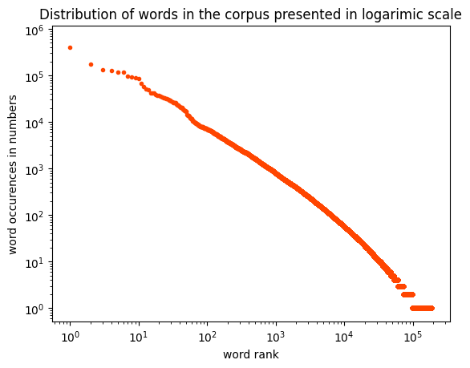

```python
global_frequencies_sorted_df = global_frequencies_df.sort_values(by = 'global_frequency', ascending = False).reset_index()

fig = plt.figure()
plt.xscale('log')
plt.yscale('log')
plt.plot(global_frequencies_sorted_df['global_frequency'], '.', c = 'orangered')
plt.title('Distribution of words in the corpus presented in logarimic scale')
plt.xlabel('word rank')
plt.ylabel('word occurences in numbers')
plt.show()
```

## Task 5

Apply a distortion function to the queries part of the corpus. In each query draw randomly one word and change one letter in the word to some other letter.

```python
fiqa_pl_queries_df = load_dataset('clarin-knext/fiqa-pl', 'queries')['queries'].to_pandas()
fiqa_pl_test_df = load_dataset('clarin-knext/fiqa-pl-qrels', 'default')['test'].to_pandas()
```

```python
fiqa_pl_queries_df.head()
```

|  | _id | title | text |
| --- | --- | --- | --- |
| 0 | 0 |  | Co jest uważane za wydatek służbowy w podróży służbowej? |
| 1 | 4 |  | Wydatki służbowe - ubezpieczenie samochodu podlegające odliczeniu za wypadek, który wydarzył się podczas podróży służbowej |
| 2 | 5 |  | Rozpoczęcie nowego biznesu online |
| 3 | 6 |  | „Dzień roboczy” i „termin płatności” rachunków |
| 4 | 7 |  | Nowy właściciel firmy – Jak działają podatki dla firmy i osoby fizycznej? |

```python
fiqa_pl_test_df.head()
```

|  | query-id | corpus-id | score |
| --- | --- | --- | --- |
| 0 | 8 | 566392 | 1 |
| 1 | 8 | 65404 | 1 |
| 2 | 15 | 325273 | 1 |
| 3 | 18 | 88124 | 1 |
| 4 | 26 | 285255 | 1 |

```python
def distort_word(word):
    letter_idx = random.randint(0, len(word) - 1)
    random_letter = random.choice(list(string.ascii_letters))

    while word[letter_idx].lower() == random_letter.lower():
        random_letter = random.choice(list(string.ascii_letters))

    word = list(word)
    word[letter_idx] = random_letter

    return ''.join(word)

def distort_query(query):
    query_tokens = [token.text for token in nlp(query)]
    word_tokens = [token.text for token in nlp(query) if token.is_alpha]

    if not word_tokens:
        return query, None

    token_idx = random.randint(0, len(query_tokens) - 1)

    while query_tokens[token_idx] not in word_tokens:
        token_idx = random.randint(0, len(query_tokens) - 1)

    distorted_word = distort_word(query_tokens[token_idx])
    query_tokens[token_idx] = distorted_word

    return ' '.join(query_tokens), distorted_word
```

```python
fiqa_pl_queries_df[['distorted_text', 'distorted_word']] = fiqa_pl_queries_df['text'].apply(lambda query: pd.Series(distort_query(query)))
```

```python
fiqa_pl_queries_df.head()
```

|  | _id | title | text | distorted_text | distorted_word |
| --- | --- | --- | --- | --- | --- |
| 0 | 0 |  | Co jest uważane za wydatek służbowy w podróży służbowej? | Co Kest uważane za wydatek służbowy w podróży służbowej ? | Kest |
| 1 | 4 |  | Wydatki służbowe - ubezpieczenie samochodu podlegające odliczeniu za wypadek, który wydarzył się podczas podróży służbowej | Wydatki służbowe - ubezpieczenie samochodu podlegające odliczeniu za wypadek , który wydarzył się podczaI podróży służbowej | podczaI |
| 2 | 5 |  | Rozpoczęcie nowego biznesu online | Rozpoczęcie nowego Ziznesu online | Ziznesu |
| 3 | 6 |  | „Dzień roboczy” i „termin płatności” rachunków | „ Dzień roboczy ” i „ termin płatności ” rachuPków | rachuPków |
| 4 | 7 |  | Nowy właściciel firmy – Jak działają podatki dla firmy i osoby fizycznej? | Nowy właściciel firmy – Jak działajR podatki dla firmy i osoby fizycznej ? | działajR |

## Task 6

Compute NDCG@10 for the distorted queries, using the same approach as in lab 2. This result will be the baseline for the other methods.

```python
es = Elasticsearch(
    'https://host.docker.internal:9200',
    verify_certs = False,
    basic_auth = ('elastic', 'B96cbDsJJzL6AV9nArVs'))

print(es.info())
```

```
{'name': 'a02ac4a4f9f8', 'cluster_name': 'docker-cluster', 'cluster_uuid': '12NhjPSCTn6AuGdMKGOyDg', 'version': {'number': '8.15.3', 'build_flavor': 'default', 'build_type': 'docker', 'build_hash': 'f97532e680b555c3a05e73a74c28afb666923018', 'build_date': '2024-10-09T22:08:00.328917561Z', 'build_sna…
```

```python
index_configuration = {
    'settings': {
        'analysis': {
            'analyzer': {
                'polish_analyzer_lemmatization': {
                    'type': 'custom',
                    'tokenizer': 'standard',
                    'filter': [
                        'lowercase',
                        'morfologik_stem',
                        'lowercase'
                    ]
                },
            }
        }
    },
    'mappings': {
        'properties': {
            'text_with_lemmatization': {
                'type': 'text',
                'analyzer': 'polish_analyzer_lemmatization'
            }
        }
    }
}
```

```python
#es.indices.delete(index = 'fiqa_pl_index')
es.indices.create(index = 'fiqa_pl_index', body = index_configuration)
```

```
ObjectApiResponse({'acknowledged': True, 'shards_acknowledged': True, 'index': 'fiqa_pl_index'})
```

```python
fiqa_pl_text_list = fiqa_pl_df.to_dict('records')
```

```python
fiqa_pl_text_list[:4]
```

```
[{'_id': '3',
  'title': '',
  'text': 'Nie mówię, że nie podoba mi się też pomysł szkolenia w miejscu pracy, ale nie możesz oczekiwać, że firma to zrobi. Szkolenie pracowników to nie ich praca – oni tworzą oprogramowanie. Być może systemy edukacyjne w Stanach Zjednoczonych (lub ich studenci) powinny trochę martwić się o zdobyc…
 {'_id': '31',
  'title': '',
  'text': 'Tak więc nic nie zapobiega fałszywym ocenom poza dodatkową kontrolą ze strony rynku/inwestorów, ale istnieją pewne nowsze kontrole, które uniemożliwiają instytucjom korzystanie z nich. W ramach DFA banki nie mogą już polegać wyłącznie na ratingach kredytowych jako należytej staranności pr…
 {'_id': '56',
  'title': '',
  'text': 'Nigdy nie możesz korzystać z FSA dla indywidualnych składek na ubezpieczenie zdrowotne. Co więcej, sponsorzy planu FSA mogą ograniczyć to, co chcą zwrócić. Chociaż nie możesz użyć FSA zdrowia do składek, wcześniej można było użyć planu kafeteryjnego 125 do opłacania składek, ale musiały t…
 {'_id': '59',
  'title': '',
  'text': 'Samsung stworzył LCD i inne technologie płaskiego ekranu, takie jak OLED. kilka lat temu każdy płaski ekran pochodził z fabryk Samsunga i był wymieniany. Myślę, że ekran 21 Hanns, na który teraz patrzę, to Samsung i ma zaledwie kilka lat. Samsung wydaje się być dobrą firmą.'}]
```

```python
def index_textual_data(iterable_data):
    iterable_actions = [
    {'_op_type': 'index',
     '_index': 'fiqa_pl_index',
     '_source': {
        'text_with_lemmatization': element['text'],
        'title': element['title'],
        'id': element['_id']
        }
    }
    for element in iterable_data]

    return iterable_actions

helpers.bulk(es, index_textual_data(fiqa_pl_text_list))
```

```
(57638, [])
```

In this task, I updated the code below from Lab 2 by adding optional advanced fuzzy parameters for Elasticsearch's fuzzy approach. As a result, this code can now be used for different approaches.

```python
def search_answers_ids(es, index_name, query, analyzer, text, k, fuzzy):
    body_query = {
        'query': {
            'match': {
                text: {
                    'query': query,
                    'analyzer': analyzer
                }
            }
        },
        '_source': ['id']
    }

    if fuzzy:
        body_query['query']['match'][text].update(fuzzy)

    response = es.search(index = index_name, body = body_query)['hits']['hits'][:k]
    return [hit['_source']['id'] for hit in response]

def compute_ncdgk(answers_ids, revelant_ids, k):
    dcg = sum(1 / math.log(i + 2, 2) for i in range(k) if int(answers_ids[i]) in revelant_ids)
    idcg = sum(1 / math.log(i + 2, 2) for i in range(min(len(revelant_ids), k)))

    return dcg / idcg

def compute_analyzer_mean_ncdgn(analyzer, text, analysed_col, k, fuzzy = None):
    ncdgk_scores = []

    for query_id in fiqa_pl_test_df['query-id'].unique():
        query = fiqa_pl_queries_df[str(query_id) == fiqa_pl_queries_df['_id']].iloc[0][analysed_col]
        answers_ids = search_answers_ids(es, 'fiqa_pl_index', query, analyzer, text, k, fuzzy)
        relevant_ids = fiqa_pl_test_df[query_id == fiqa_pl_test_df['query-id']]['corpus-id'].tolist()
        ncdgk_score = compute_ncdgk(answers_ids, relevant_ids, k = k)
        ncdgk_scores.append(ncdgk_score)

    return np.mean(ncdgk_scores)
```

It is worth mentioning that I created a nested dictionary to store the results of specific experiments. All results are displayed and compared in Task 11.

```python
results_dict = {
    'Baseline': {'NDCG@10': None, 'Performance': None},
    'Levenshtein': {'NDCG@10': None, 'Performance': None},
    'Fuzzy': {'NDCG@10': None, 'Performance': None}
}
```

```python
start = time.time()
results_dict['Baseline']['NDCG@10'] = compute_analyzer_mean_ncdgn('polish_analyzer_lemmatization', 'text_with_lemmatization', 'distorted_text', 10)
end = time.time()

results_dict['Baseline']['Performance'] = end - start

print(f"Mean NCDG@10: {results_dict['Baseline']['NDCG@10']}")
```

```
Mean NCDG@10: 0.19390301741775065
```

## Task 7

Install [Morfeusz](http://morfeusz.sgjp.pl/download/) (Binding dla Pythona) and use it to find all words from the queries that do not appear in that dictionary. Only these words should be corrected in the next step. This step is not obligatory - if there's a problem installing Morfeusz, you can use one of the raw text files (Morfeusz "Słownik Polimorf" or "Słownik SGJP") and use the first column, as a list of all valid forms in Polish.

```python
morpheus = Morfeusz()

def find_incorrect_words(text):
    return [interpretation[2][0] for interpretation in morpheus.analyse(text) if interpretation[2][2] == 'ign']
```

```python
fiqa_pl_queries_df['invalid_words'] = fiqa_pl_queries_df['distorted_text'].apply(find_incorrect_words)
```

```python
fiqa_pl_queries_df.head()
```

|  | _id | title | text | distorted_text | distorted_word | invalid_words |
| --- | --- | --- | --- | --- | --- | --- |
| 0 | 0 |  | Co jest uważane za wydatek służbowy w podróży służbowej? | Co Kest uważane za wydatek służbowy w podróży służbowej ? | Kest | [Kest] |
| 1 | 4 |  | Wydatki służbowe - ubezpieczenie samochodu podlegające odliczeniu za wypadek, który wydarzył się podczas podróży służbowej | Wydatki służbowe - ubezpieczenie samochodu podlegające odliczeniu za wypadek , który wydarzył się podczaI podróży służbowej | podczaI | [] |
| 2 | 5 |  | Rozpoczęcie nowego biznesu online | Rozpoczęcie nowego Ziznesu online | Ziznesu | [Ziznesu] |
| 3 | 6 |  | „Dzień roboczy” i „termin płatności” rachunków | „ Dzień roboczy ” i „ termin płatności ” rachuPków | rachuPków | [rachuPków] |
| 4 | 7 |  | Nowy właściciel firmy – Jak działają podatki dla firmy i osoby fizycznej? | Nowy właściciel firmy – Jak działajR podatki dla firmy i osoby fizycznej ? | działajR | [działajR] |

Obtained results indicate that Morfeusz finds distorted words quite well. Of course, sometimes it fails to do that or a distorted word can accidentally be similar to an existing word. In such cases returned list is empty.

```python
fiqa_pl_queries_df[30:40]
```

|  | _id | title | text | distorted_text | distorted_word | invalid_words |
| --- | --- | --- | --- | --- | --- | --- |
| 30 | 48 |  | Czy biznes mojego męża powinien opłacać mój biznes? | Czy biznes mooego męża powinien opłacać mój biznes ? | mooego | [mooego] |
| 31 | 49 |  | Dlaczego nie można realizować transakcji online poza godzinami pracy? | Dlaczego nie można reaHizować transakcji online poza godzinami pracy ? | reaHizować | [reaHizować] |
| 32 | 51 |  | Praca na pełen etat + prowadzenie małej firmy: Najlepsza struktura biznesowa dla podatków? | Praca Ma pełen etat + prowadzenie małej firmy : Najlepsza struktura biznesowa dla podatków ? | Ma | [] |
| 33 | 52 |  | Nowy biznes związany z trasami vendingowymi, nie wiem, jak określić podatki | NoTy biznes związany z trasami vendingowymi , nie wiem , jak określić podatki | NoTy | [vendingowymi] |
| 34 | 53 |  | Znalezienie dobrego CPA dla małej firmy? | Znalezienie dobrego CPA vla małej firmy ? | vla | [CPA, vla] |
| 35 | 54 |  | Dochód podlegający opodatkowaniu z pracy w pełnym wymiarze godzin + zarobki z działalności gospodarczej | Dochód podlegający opodatkowaniu z pracy Z pełnym wymiarze godzin + zarobki z działalności gospodarczej | Z | [] |
| 36 | 57 |  | Jak mogę wyszukać firmę powiązaną z FEIN? | Jak mogę wyszukać firmę powiązaną z wEIN ? | wEIN | [wEIN] |
| 37 | 59 |  | Alokacja podatku — transfer aktywów firmy | Alokacja podatku — tUansfer aktywów firmy | tUansfer | [tUansfer] |
| 38 | 61 |  | Jak odliczyć składki rodzinnej opieki zdrowotnej w ramach działalności dodatkowej? | Jak odliczyć składki roNzinnej opieki zdrowotnej w ramach działalności dodatkowej ? | roNzinnej | [roNzinnej] |
| 39 | 62 |  | Odszkodowanie za samochód jako wydatek biznesowy w Wielkiej Brytanii | Odszkodowanie ka samochód jako wydatek biznesowy w Wielkiej Brytanii | ka | [] |

However, sometimes Morfeusz identifies more unknown words, such as those from foreign languages, personal names, etc. These words, of course, are not included in the Polish Morfeusz dictionary. For the purposes of this task, these words will be excluded from the correction process, as they were not intentionally distorted.

```python
fiqa_pl_queries_df['invalid_words'] = fiqa_pl_queries_df.apply(lambda row: [row['distorted_word']] if row['distorted_word'] in row['invalid_words']
                                                                else [], axis = 1)
```

```python
fiqa_pl_queries_df[30:40]
```

|  | _id | title | text | distorted_text | distorted_word | invalid_words |
| --- | --- | --- | --- | --- | --- | --- |
| 30 | 48 |  | Czy biznes mojego męża powinien opłacać mój biznes? | Czy biznes mooego męża powinien opłacać mój biznes ? | mooego | [mooego] |
| 31 | 49 |  | Dlaczego nie można realizować transakcji online poza godzinami pracy? | Dlaczego nie można reaHizować transakcji online poza godzinami pracy ? | reaHizować | [reaHizować] |
| 32 | 51 |  | Praca na pełen etat + prowadzenie małej firmy: Najlepsza struktura biznesowa dla podatków? | Praca Ma pełen etat + prowadzenie małej firmy : Najlepsza struktura biznesowa dla podatków ? | Ma | [] |
| 33 | 52 |  | Nowy biznes związany z trasami vendingowymi, nie wiem, jak określić podatki | NoTy biznes związany z trasami vendingowymi , nie wiem , jak określić podatki | NoTy | [] |
| 34 | 53 |  | Znalezienie dobrego CPA dla małej firmy? | Znalezienie dobrego CPA vla małej firmy ? | vla | [vla] |
| 35 | 54 |  | Dochód podlegający opodatkowaniu z pracy w pełnym wymiarze godzin + zarobki z działalności gospodarczej | Dochód podlegający opodatkowaniu z pracy Z pełnym wymiarze godzin + zarobki z działalności gospodarczej | Z | [] |
| 36 | 57 |  | Jak mogę wyszukać firmę powiązaną z FEIN? | Jak mogę wyszukać firmę powiązaną z wEIN ? | wEIN | [wEIN] |
| 37 | 59 |  | Alokacja podatku — transfer aktywów firmy | Alokacja podatku — tUansfer aktywów firmy | tUansfer | [tUansfer] |
| 38 | 61 |  | Jak odliczyć składki rodzinnej opieki zdrowotnej w ramach działalności dodatkowej? | Jak odliczyć składki roNzinnej opieki zdrowotnej w ramach działalności dodatkowej ? | roNzinnej | [roNzinnej] |
| 39 | 62 |  | Odszkodowanie za samochód jako wydatek biznesowy w Wielkiej Brytanii | Odszkodowanie ka samochód jako wydatek biznesowy w Wielkiej Brytanii | ka | [] |

## Task 8

Use Levenshtein distance and the frequency list, to determine the most probable correction of the words in the queries that were identified as invalid. (**Note**: You don't have to apply the distance directly. Any method that is more efficient than scanning the dictionary will be appreciated.)

In this task I decided to use [Polyleven](https://ceptord.net/20181215-polyleven.html) Levenshtein distance library, with special attention to efficiency. The measurements provided on its website indicate that it is more efficient than the Levenshtein library.

```python
from polyleven import levenshtein

def find_correction(invalid_word, frequency_dict):
    suggestions = sorted([(word, levenshtein(invalid_word, word)) for word in frequency_dict.keys()], key = lambda x: x[1])
    return suggestions[0][0]
```

I am computing the Levenshtein performance as the sum of processing and query execution times. First, I measure the processing time.

```python
start = time.time()
fiqa_pl_queries_df['corrected_words_lev'] = fiqa_pl_queries_df['invalid_words'].apply(lambda words: [find_correction(word, token_global_frequencies_dict) for word in words])
end = time.time()

lev_processing_time = end - start
print(f'Levenshtein processing time: {lev_processing_time}')
```

```
Levenshtein processing time: 524.3420822620392
```

```python
fiqa_pl_queries_df.head()
```

[output not shown]

## Task 9

Compute NDCG@10 for your implementation of the spelling correction method.

```python
def correct_distorted_text(row):
    text = row['distorted_text']

    for invalid_word, corrected_word in zip(row['invalid_words'], row['corrected_words_lev']):
        if invalid_word in row['distorted_text']:
            text = text.replace(invalid_word, corrected_word)

    return text
```

```python
start = time.time()
fiqa_pl_queries_df['corrected_text_lev'] = fiqa_pl_queries_df.apply(correct_distorted_text, axis = 1)
end = time.time()

lev_processing_time += end - start
print(f'Levenshtein processing time: {lev_processing_time}')
```

```
Levenshtein processing time: 524.4019315242767
```

```python
fiqa_pl_queries_df.head()
```

|  | _id | title | text | distorted_text | distorted_word | invalid_words | corrected_words_lev | corrected_text_lev |
| --- | --- | --- | --- | --- | --- | --- | --- | --- |
| 0 | 0 |  | Co jest uważane za wydatek służbowy w podróży służbowej? | Co Kest uważane za wydatek służbowy w podróży służbowej ? | Kest | [Kest] | [jest] | Co jest uważane za wydatek służbowy w podróży służbowej ? |
| 1 | 4 |  | Wydatki służbowe - ubezpieczenie samochodu podlegające odliczeniu za wypadek, który wydarzył się podczas podróży służbowej | Wydatki służbowe - ubezpieczenie samochodu podlegające odliczeniu za wypadek , który wydarzył się podczaI podróży służbowej | podczaI | [] | [] | Wydatki służbowe - ubezpieczenie samochodu podlegające odliczeniu za wypadek , który wydarzył się podczaI podróży służbowej |
| 2 | 5 |  | Rozpoczęcie nowego biznesu online | Rozpoczęcie nowego Ziznesu online | Ziznesu | [Ziznesu] | [biznesu] | Rozpoczęcie nowego biznesu online |
| 3 | 6 |  | „Dzień roboczy” i „termin płatności” rachunków | „ Dzień roboczy ” i „ termin płatności ” rachuPków | rachuPków | [rachuPków] | [rachunków] | „ Dzień roboczy ” i „ termin płatności ” rachunków |
| 4 | 7 |  | Nowy właściciel firmy – Jak działają podatki dla firmy i osoby fizycznej? | Nowy właściciel firmy – Jak działajR podatki dla firmy i osoby fizycznej ? | działajR | [działajR] | [działają] | Nowy właściciel firmy – Jak działają podatki dla firmy i osoby fizycznej ? |

```python
start = time.time()
results_dict['Levenshtein']['NDCG@10'] = compute_analyzer_mean_ncdgn('polish_analyzer_lemmatization', 'text_with_lemmatization', 'corrected_text_lev', 10)
end = time.time()

lev_query_execution_time = end - start
print(f'Levenshtein query execution time: {lev_query_execution_time}')

results_dict['Levenshtein']['Performance'] = lev_query_execution_time + lev_processing_time

print(f"Mean NCDG@10: {results_dict['Levenshtein']['NDCG@10']}")
```

```
Levenshtein query execution time: 4.302153825759888
Mean NCDG@10: 0.20206324260505523
```

## Task 10

Use ElasticSearch's fuzzy match and compute NDCG@10 for this approach.

```python
fuzzy_dict = {
    'fuzziness': 2,
    'max_expansions': 2,
    'prefix_length': 0
}

start = time.time()
results_dict['Fuzzy']['NDCG@10'] = compute_analyzer_mean_ncdgn('polish_analyzer_lemmatization', 'text_with_lemmatization', 'distorted_text', 10, fuzzy_dict)
end = time.time()

results_dict['Fuzzy']['Performance'] = end - start

print(f"Mean NCDG@10: {results_dict['Fuzzy']['NDCG@10']}")
```

```
Mean NCDG@10: 0.19807639575768274
```

## Task 11

Compare the results of baseline with the 2 implemented methods. Take into account the NDCG score and the performance of the methods.

First, I check the original NDCG@10, where the original, non-distorted queries are used.

```python
print(f"Mean NCDG@10: {compute_analyzer_mean_ncdgn('polish_analyzer_lemmatization', 'text_with_lemmatization', 'text', 10)}")
```

```
Mean NCDG@10: 0.20705719453326424
```

Then, I compare the results of baseline (used distorted text) with the 2 implemented methods.

```python
df_results = pd.DataFrame(results_dict).T
df_results
```

|  | NDCG@10 | Performance |
| --- | --- | --- |
| Baseline | 0.193903 | 5.179474 |
| Levenshtein | 0.202063 | 528.704085 |
| Fuzzy | 0.198076 | 11.692873 |

The obtained results indicate that in this case, NDCG@10 for Levenshtein and Elasticsearch's fuzzy approach were close to each other. Both NDCG@10 values were higher than the baseline NDCG@10, suggesting that both methods were successful to some extent in correcting distorted queries. It should be mentioned that the results for Levenshtein and Elasticsearch's fuzzy may vary depending on the implementation and the parameters used (especially fuzzy). When it comes to performance, it is noticeable that the manually implemented Levenshtein has a longer processing time. On the other hand, solutions provided by Elasticsearch are quite fast.

## Task 12

Use an LLM of your choice (you can use [Bielik](https://chat.bielik.ai/)) to fix 30 first queries from the distorted set and compare the results manually with the method based on the Levenshtein distance.

I decided to use LLM called Gemini 1.5 Flash model provided by Google in order to fix 30 first queries from the distorted set.

```python
fiqa_pl_queries_df[['distorted_text', 'corrected_text_lev']][:30]
```

|  | distorted_text | corrected_text_lev |
| --- | --- | --- |
| 0 | Co Kest uważane za wydatek służbowy w podróży służbowej ? | Co jest uważane za wydatek służbowy w podróży służbowej ? |
| 1 | Wydatki służbowe - ubezpieczenie samochodu podlegające odliczeniu za wypadek , który wydarzył się podczaI podróży służbowej | Wydatki służbowe - ubezpieczenie samochodu podlegające odliczeniu za wypadek , który wydarzył się podczaI podróży służbowej |
| 2 | Rozpoczęcie nowego Ziznesu online | Rozpoczęcie nowego biznesu online |
| 3 | „ Dzień roboczy ” i „ termin płatności ” rachuPków | „ Dzień roboczy ” i „ termin płatności ” rachunków |
| 4 | Nowy właściciel firmy – Jak działajR podatki dla firmy i osoby fizycznej ? | Nowy właściciel firmy – Jak działają podatki dla firmy i osoby fizycznej ? |
| 5 | vobby kontra biznes | hobby kontra biznes |
| 6 | Czeki osoWiste zamiast firmowych | Czeki osobiste zamiast firmowych |
| 7 | Czy amerykański kodeks podatkowy wymaga , aby właścicielk małych firm liczyli zakupy biznesowe jako dochód osobisty ? | Czy amerykański kodeks podatkowy wymaga , aby właściciele małych firm liczyli zakupy biznesowe jako dochód osobisty ? |
| 8 | Jak mogę zarejestrować firmę w Wielkiej Brytanii buz podawania adresu firmy ? | Jak mogę zarejestrować firmę w Wielkiej Brytanii buz podawania adresu firmy ? |
| 9 | Czom są „ podstawy biznesowe ” ? | dom są „ podstawy biznesowe ” ? |
| 10 | StrOta na inwestycjach biznesowych z poprzedniego roku | strata na inwestycjach biznesowych z poprzedniego roku |
| 11 | Jak aogę oszacować podatki biznesowe / opłaty za zgłoszenie dla firmy , która ma 0 USD dochodu ? | Jak mogę oszacować podatki biznesowe / opłaty za zgłoszenie dla firmy , która ma 0 USD dochodu ? |
| 12 | Czy zakup samochodu dla firmy za pomocą kredytu biznesowego zostałby uznany za wNdatek biznesowy ? | Czy zakup samochodu dla firmy za pomocą kredytu biznesowego zostałby uznany za wydatek biznesowy ? |
| 13 | Odliczanie strat biznesowych z ostatnich lat ( nieudoXumentowanych ) | Odliczanie strat biznesowych z ostatnich lat ( nieudokumentowanych ) |
| 14 | 30 % udziału w bizWesie | 30 % udziału w biznesie |
| 15 | Odbieranie wydatków służbowych z osobistej garty kredytowej | Odbieranie wydatków służbowych z osobistej karty kredytowej |
| 16 | Używanie czeku biznesowego dQ płatności w handlu detalicznym | Używanie czeku biznesowego do płatności w handlu detalicznym |
| 17 | Podatek przy zakładaniu firmy w pełnym wymiarze czasu pvacy | Podatek przy zakładaniu firmy w pełnym wymiarze czasu pracy |
| 18 | Czy mogę spłacić saldo karty kredytowej , aby zwoFnić dostępny kredyt ? | Czy mogę spłacić saldo karty kredytowej , aby zwolnić dostępny kredyt ? |
| 19 | Powolne rozpoczynanie działalnSści pobocznej | Powolne rozpoczynanie działalności pobocznej |
| 20 | Dlaczego „ spieniężanie czeków ” jest legaYną działalnością ? | Dlaczego „ spieniężanie czeków ” jest legalną działalnością ? |
| 21 | Czy biznes to jedyny sposób na zostfnie milionerem ? | Czy biznes to jedyny sposób na zostanie milionerem ? |
| 22 | Wycenianie małej firmy , w którO warto zainwestować | Wycenianie małej firmy , w które warto zainwestować |
| 23 | Rozpoczęcie dużego biznGsu z niezbyt dużymi dochodami ? | Rozpoczęcie dużego biznesu z niezbyt dużymi dochodami ? |
| 24 | Wymagania dotyczące rozliczania poUatków biznesowych ? | Wymagania dotyczące rozliczania podatków biznesowych ? |
| 25 | IXA do pracy i mojej firmy | nie do pracy i mojej firmy |
| 26 | Doradztwo M zakresie transferu pieniędzy | Doradztwo M zakresie transferu pieniędzy |
| 27 | Jak przenieść leasiny samochodu osobistego do leasingu samochodu biznesowego ? | Jak przenieść leasing samochodu osobistego do leasingu samochodu biznesowego ? |
| 28 | Korepetycje b zarządzania płacami biznesowymi | Korepetycje b zarządzania płacami biznesowymi |
| 29 | Czy jako Głaściciel małej firmy powinienem płacić podatki z mojego osobistego lub firmowego konta czekowego ? | Czy jako właściciel małej firmy powinienem płacić podatki z mojego osobistego lub firmowego konta czekowego ? |

[figure not shown]

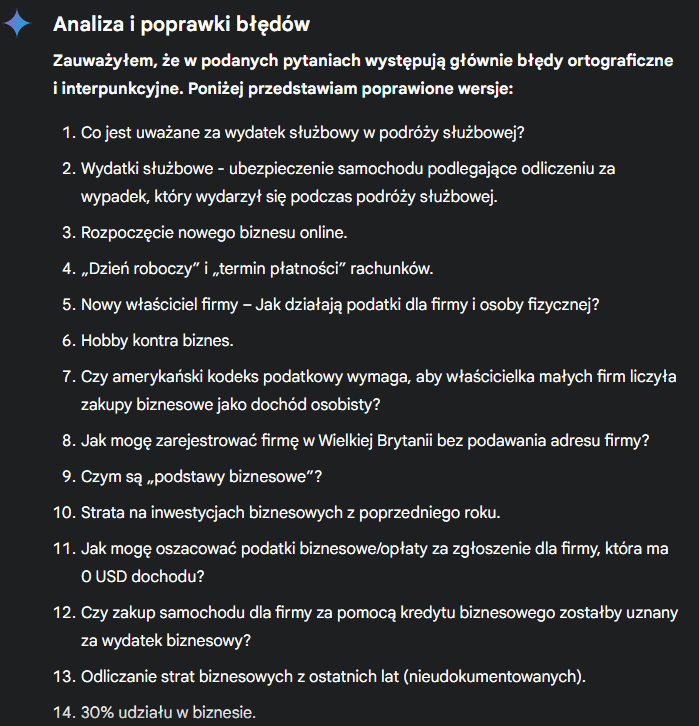

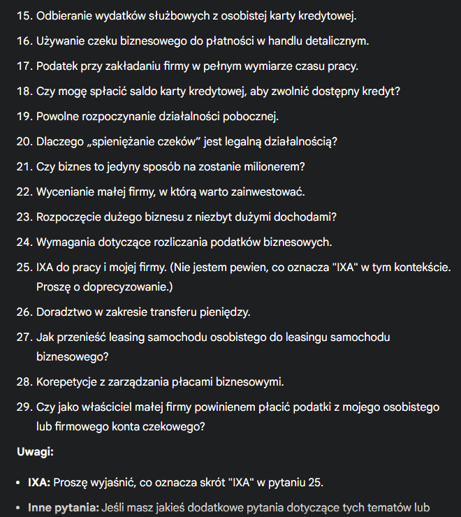

## Draw conclusions

### Conclusion 1

Draw conclusions regarding the distribution of words in the corpus.

The distribution of words in the corpus, presented in logarithmic scale on the plot, suggests a linear relationship. Therefore, I can conclude that the relationship between a word's rank and the number of its occurrences follows a power-law distribution. By observing this plot, I can also infer that the majority of commonly used words in daily activities are located at the beginning of the plot, where occurrences are the highest.

### Conclusion 2

Draw conclusions regarding the performance of your method compared to ElasticSearch.

The obtained performance results indicate that, in this case, the Levenshtein method performed poorly compared to Elasticsearch's fuzzy approach. For Levenshtein, the processing step and query execution together took about 528 seconds. The longest part was the processing step, where I used Levenshtein to correct invalid words. I suspect that the way I applied it to this dataset caused the slow performance.

On the other hand, Elasticsearch's fuzzy approach handled distorted queries efficiently, taking only about 11 seconds. This efficiency was significantly influenced by the chosen parameters, as highlighted in the official documentation. Considering the fact that Elasticsearch's fuzzy method was specifically designed to handle large datasets efficiently, it is not surprising that my Levenshtein implementation resulted in a much longer processing time.

### Conclusion 3 - 4

Draw conclusions regarding the results provided by your method compared to ElasticSearch.  
Draw conclusions regarding the validity of the obtained corrections.

Obtained NDCG@10 values for ElasticSearch's fuzzy and Levenshtein are close to each other due to enhanced parameters. They are also higher than the baseline NDCG@10, suggesting that both methods were successful to some extent in correcting distorted queries. The higher value NDCG@10 is for Levenshtein. I suspect it is a result of dynamically comparing each word to others without constraints like max_expansions in fuzzy.

I have noticed that in scenarios where a distorted word formed another valid word, the Levenshtein method did not correct it, in contrast to ElasticSearch's fuzzy approach. It is caused by the fact that Levenshtein focuses on minimizing edit distance without considering the context, which can lead to incorrect corrections when multiple valid alternatives exist.

### Conclusion 5

Draw conclusions regarding ability of an LLM to fix invalid queries.

After examining the first 30 queries from the distorted set, returned by LLM, I conclude that LLM is capable of fixing invalid queries. It performs this task quite well, provided it does not omit any distorted question from the given list. More details about LLM's capabilities on this topic are discussed in Task 12.